# CS102/CS103: Week 10 - Files again (V1.0)

**Lecture notes for Week 10 of CS102/CS103, 30 November + 1 December, 2022.**

Dr Niall Madden, School of Mathematical and Statistical Sciences, University of Galway.

You can find these notes at:

- https://www.niallmadden.ie/2223-CS103 - HTML, Slides, and downloadable `.ipynb` files
- Jupyter notebook on **Binder** https://mybinder.org/v2/gh/niallmadden/2223-cs103/main
- Both formats on Github: https://github.com/niallmadden/2223-cs103

Links also on Blackboard.

*This notebook was written by Niall Madden, and uses some material from [Think Python](https://greenteapress.com/thinkpython2/html).*

## What we are doing this week:

2. Recap on reading from files
3. Recap on if-statements
4. How to time code, and to speed it up.
5. How to *write* to a file.
6. AMA
7. Functions and default value
8. The best starting guess for Wordle.
9. Analysing some old books

## News

### Lab 7 this week

Lab 7 uses the same system as Lab 6 for fetching and submitting your lab work. Have a look at the video for an explanation, as well as the solution to the first task.

For it, you must use the Jupyter server at https://cloudjupyter.universityofgalway.ie/. Check your email for a message from `maths-sto@universityofgalway.ie` with your username and password.

**Deadline**: Friday, 02 December at 5pm.

### Plans for the rest of the semester

Next week is the final week of labs. There will be some changes some changes to the venues:

- Tuesday (6th December) **MY127** instead of AMB-1024
- Wednesday (7th December) **MY127** instead of BLE-2012 both days.

You'll need to bring your own laptop to MY127. If that is a problem, contact Niall.

The Monday and Wednesday labs in the Cairnes Building will go ahead as usual.

### Assessment Summary

The assessment for CS103, and this part of CS102 is as follows:

### Class test in Week 12

There will be a test during Wednesday of Week 12. It should be possible to complete in under an hour. However...

1. The test will be on fundamental topics in Python, up to, but not including dictionaries.
2. It will be online, though you are welcome to come to the lecture and do it there, and ask questions.
3. It is designed to take no more than 50 minutes, but everyone will have 2 hours to complete it. (Will confirm exact details next week: **do you have any other tests that day??**.
4. You can do the test anywhere you want.
5. It is "Open Book": you any resources you like (but not contract cheating!).
6. But you *can* collaborate with class-mates.

# Files (Part 2)

In Week 8 we learned how to read data from files. Now we want to learn how to *write* data to a file.

First we'll recap reading from a file, and then finish an example from last week.

## Opening a file for reading

Basic idea: *to open a file called `words.txt`, and attach it to the identifier `words_file` use*

```
words_file = open("words.txt")
```

To avoid errors should the file not exist, we should use `try... except`.

```python
file_name = "words.txt"
try:
    words_file = open(file_name)
    print(f"Opened {file_name} successfully")
except:
    print(f"Sorry - could not open {file_name}.")
```

```
Opened words.txt successfully
```

## Reading from a file

You'll recall that

- `words.txt` is a file that comes with the textbook (Think Python)
- it contains a list of 113,783 words in the English language
- it has one word per line
- the *invisible* new-line `\n` character follows each word.

```
aa
aah
aahed
aahing
aahs
aal
aalii
aaliis
aals
aardvark
```

There are numerous ways to read from a file. In this example, we'll use a `for` loop to read all the words from the file, and store them in a list called `all_the_words`.

```python
all_the_words = []
for line in words_file:
    word = line.strip() # remove the end-of-line `\n`
    all_the_words += [word] # Add that word as an item to the list
```

```python
index_list = [10, 18656, 48593, 78818]
for i in index_list:
    print(all_the_words[i], end=" -- ")
```

```
aardvarks -- code -- in -- python --
```

# `if`-statements again

## Recap

Some weeks ago we learned that the format for an `if`-statement in Python is:

```
if <boolean_exp_1>:
    <body_1>  # do this if boolean_exp_1 is True
elif <boolean_exp_2>:
    <body_2>  # do this if boolean_exp_1 is False. but boolean_exp_2 is True
# ...
elif <condition_n>:
    <body_n>
else:      # do this none of the boolean_exp are True
    <body_0>
```

(*The following is an old programming joke*). Suppose we wanted to check if an number between 0 and 4 is even or odd. We could do it like this (badly):

```python
n = int(input("Enter a number between 0 and 4: "))
if (n==0):
    print(f"{n} is even")
elif (n == 1):
    print(f"{n} is odd")
elif (n == 2):
    print(f"{n} is even")
elif (n == 3):
    print(f"{n} is odd")
elif (n == 4):
    print(f"{n} is even")
else:
    print(f"Sorry: {n} is not in range")
```

```
Enter a number between 0 and 4: 3
3 is odd
```

## `if`-statements: short circuting

We also learned how to use the operators: `and`, and `or`.

A *Boolean Expression* is one that evaluates as either `True` or `False` (which are built-in literals).

For example, if `A` and `B` are Boolean, then

- `A and B` is `True` only if **both** `A` and `B` are `True`. That is the same as saying:
- `A and B` is `False` if **either** `A` or `B` are `False`.
- `A or B` is `True` if **either** `A` or `B` are `True`. That is the same as saying:
- `A or B` is `False` only if **both** `A` and `B` are `False`.

But in fact, something more subtle is true... Let's look at an example first.

First we'll define some simple functions that evaluate as `True` and `False`.

```python
def ThisIsTrue():
    print(" **--Function ThisIsTrue()  called--**")
    return True

def ThisIsFalse():
    print(" **--Function ThisIsFalse() called--**")
    return False
```

Let's check happens when we call this:

```python
x = ThisIsTrue() and ThisIsFalse()
print(f"x = {x}")
```

```
 **--Function ThisIsTrue()  called--**
 **--Function ThisIsFalse() called--**
x = False
```

We see output from both functions, which is what we expected, right?

Let's try that again, but with an `or` statement:

```python
y = (ThisIsFalse() or ThisIsTrue())
```

```
 **--Function ThisIsFalse() called--**
 **--Function ThisIsTrue()  called--**
```

Again, what we expected: we see output from both functions. But how about the next two examples?

```python
ThisIsFalse() and ThisIsTrue()
```

```
 **--Function ThisIsFalse() called--**
```

```
False
```

```python
ThisIsTrue() or ThisIsFalse()
```

```
 **--Function ThisIsTrue()  called--**
```

```
True
```

We only see one line of output from each! This is called *short circuiting*.

## Short circuiting.

Since

```
True or ANYTHING
```

is True no matter what `ANYTHING` is, there is no need to check the its value, or even run that code.

Similarly,

```
False and ANYTHING
```

is False irrespective of the value of `ANYTHING`. So Python does not even bother running the `ANYTHING` code.

# A 'file' example : Reverse Words

THe example is "left over" from last week. We'll make a list of words which, if reversed, give another word (in the `words.txt` file).

## Word reverser

It will be useful to have a function that returns a string reversed.

```python
def reverse(word):
    return word[::-1]
```

```python
reverse("lamina")
```

```
'animal'
```

```python
reverse("python")
```

```
'nohtyp'
```

## Timing code

There are actually quite a few "reversable" words, 885 in fact. So we'll try to find a small subset, for example, those with exactly 8 characters.

Here is some code that could be used to find all these words. Notice the use of the `and` operator.

**WARNING**: this code is VERY slow:

```
reversable = list()
for w in all_the_words:
    if (reverse(w) in all_the_words) and (len(w) == 8):
        reversable += [reverse(w)]
```

```
%%commmand
```

```python
%%time
## WARNING - this code could take several minutes to run!
reversable = list()
for w in all_the_words:
    if (reverse(w) in all_the_words) and (len(w) == 8):
        reversable += [reverse(w)]
```

```
CPU times: user 2min 45s, sys: 0 ns, total: 2min 45s
Wall time: 2min 45s
```

```python
print(f"There are {len(reversable)} eight-letter reversable words")
```

```
There are 4 eight-letter reversable words
```

**Question**: Why is it so slow?

**Answer:**: There are over 100,000 words in the file. For each of those, we compare its reversal against every other word in the file. That is 10 billion calculations!

**Question**: How can we speed this up?

**Answer**: Using short-circuiting!

In the `if` statement, we check two things:

- `reverse(w) in all_the_words`: this involves 100,000 calculations
- `len(w) == 8` this involves just 1.

Since `len(w) == 8` frequently evaluates as `False` we can save a some time by putting this first.

In this version we have just changed the order of the conditions in the `if` statement. It reduces the run-time by abut 75%.

```python
%%time
reversable = list()
for w in all_the_words:
    if (len(w) == 8) and (reverse(w) in all_the_words):
        reversable += [reverse(w)]
```

```
CPU times: user 43 s, sys: 3.97 ms, total: 43 s
Wall time: 43 s
```

```python
print(f"There are {len(reversable)} words, which are {reversable}")
```

```
There are 4 words, which are ['stressed', 'rewarder', 'redrawer', 'desserts']
```

This last example is based on Exercise 11.5 from the text. But that one is more interesting: it compiles lists of "cycled" word matches. Also, it uses a dictionary, rather than a list.

# Writing Files

(See Chapter 14 of Think Python for more details).

## Persistence

> Most of the programs we have seen so far are *transient*: they run for a short time and produce some output. When they end, their data disappears. If you run the program again, it starts with a clean slate.

> Other programs are **persistent**: they run for a long time; they keep at least some of their data in permanent storage; if they shut down and restart, they pick up where they left off.

One of the simplest ways for programs to maintain their data is by reading and **writing** text files. We've already done reading. Now we'll now do writing of files.

## Open a file for writing

SYNTAX:

```
out_file = open("newfile.txt", "w")
```

- If the file `newfile.txt` does not exist, it is created, and the program is allowed store data there.
- If the file `newfile.txt` already exists, it's old contents are deleted.

This assumes that the program is *allowed* open the file. We'll come back to this later

## Writing to a file

The simplest way to write to a file, is to use the `.write( < string > )` method which writes string to the file.

```
out_file.write( < string > )
```

writes `string` to the open file. It does not include the new-line. The function returns the number of bytes written.

When we are done, we should `close()` the file.

Here we'll

- open a file
- write two lines to it
- close the file

```python
try:
    out_file = open("newfile.txt", "w")
except:
    print("ERROR")
```

```python
out_file.write("This is Line 1\n") # notice the use of `\n`
out_file.write("This is another Line 2\n")
```

```
23
```

```python
out_file.close() # close the file
```

Finish here Wednesday

# Arcane Interlude 9: Ask me anything!

A short one this week.

```python
import wikipedia
```

```python
that_thing = input("What would you like to know about: ")
```

```
What would you like to know about: Fleetwoodmac
```

```python
that_thing_wiki = wikipedia.page(that_thing, auto_suggest=True)
```

```python
print(that_thing_wiki.summary)
```

```
Fleetwood Mac are a British-American rock band, formed in London in 1967. Fleetwood Mac were founded by guitarist Peter Green, drummer Mick Fleetwood and guitarist Jeremy Spencer, before bassist John McVie joined the line-up for their eponymous debut album. Danny Kirwan joined as a third guitarist i…
Primarily a British blues band at first, Fleetwood Mac scored a UK number one with "Albatross", and had other hits such as the singles "Oh Well", "Man of the World", and “The Green Manalishi”. All three guitarists left in succession during the early 1970s, to be replaced by guitarists Bob Welch and …
The addition of Buckingham and Nicks gave the band a more pop rock sound, and their 1975 self-titled album, Fleetwood Mac, reached No. 1 in the United States. Rumours (1977), Fleetwood Mac's second album after the arrival of Buckingham and Nicks, produced four U.S. Top 10 singles and remained at num…
The band's personnel remained stable through three more studio albums, but by the late 1980s began to disintegrate. After Buckingham and Nicks each left the band, they were replaced by a number of other guitarists and vocalists. A 1993 one-off performance for the first inauguration of Bill Clinton f…
Fleetwood Mac have sold more than 120 million records worldwide, making them one of the world's best-selling bands. In 1979, the group were honoured with a star on the Hollywood Walk of Fame. In 1998 the band were inducted into the Rock and Roll Hall of Fame and received the Brit Award for Outstandi…
```

# Functions with default values

You may have noticed yesterday that:

- To open a file for reading, we used `file_handle = open(file_name)`, and
- To open a file for writing, we used `file_handle = open(file_name, "w")`

So, sometimes `open()` takes two arguments, and sometimes just one.

This can be a but confusing: *how can a function sometimes take one argument and other times take two*?

*Answer*: because function definitions can specify default values.

## Specifying default values

Suppose we define a function that adds some numbers:

```python
def add_numbers(a, b, c, d):
    return(a + b + c + d)
```

This will work if we add 4 numbers:

```python
add_numbers(1,2,3,4)
```

```
10
```

But not if we try to add 3....

If we called `add_numbers(1,2,3)` we would get the error:

```
TypeError                                 Traceback (most recent call last)
Input In [28], in <cell line: 1>()
----> 1 add_numbers(1,2,3)

TypeError: add_numbers() missing 1 required positional argument: 'd'
```

To get around this, we can specify what values to use if the user doesn't provide them:

```python
def add_numbers(a, b, c=0, d=0):  # c and d are taken as zero if not provided
    return(a + b + c + d)
```

```python
add_numbers(1,2)
```

```
3
```

```python
add_numbers(1,2,3)
```

```
6
```

## The actual syntax for `open()`

The correct syntax for `open()` is: `handle = open(name, mode="r")` where

- `name` is a string containing the file's name;
- `mode` is a string that is one of:
  - `"r"` : *read*. The default value. Opens a file for reading.
  - `"w"` : *write*. Opens a file for writing new data to. Overwrites any existing file.
  - `"a"` : *append*. Opens a file for appending (adding) to.
  - `"x"` : like *write", but gives an error if the file exist.

# The Best Starting Guess for Wordle

**Wordle** is a word game you can find at nytimes.com/games/wordle. You have 6 guesses to find a randomly chosen 5-letter word. For each letter in guess you are told

- if the letter is present, and in the right location
- if the letter is present, but in a different location
- not in the word

[figure not shown]

```python
from IPython import display
display.Image("Wordle.png")
```

## Five letter words

Success is related to having a good starting word. And finding that depends on having a list of five-letter words. But we learned yesterday that it can be very slow to search through all 100,000 words in `words.txt`. So let's make a new file with just five-letter words.

This also allows us to practice reading and writing files in the same example.

```python
in_file = open("words.txt", "r")
out_file = open("words_five.txt", "w")
for w in in_file:
    if len(w) == 6: # includes the `\n`
        out_file.write(w)
in_file.close()
out_file.close()
```

## The most frequently occurring 5-letter words.

We did this in Week 9. Most of the following code is repeated from that, so we won't discuss it in detail.

```python
from matplotlib import pyplot as plt # for plotting the histogram
```

```python
def histogram(my_list):
    """Creates a histogram of items in my_list. Returns a dictionary,
    where d[key] is the frequency of key in the list"""
    d = dict()
    for element in my_list:
        if element not in d:
            d[element] = 1
        else:
            d[element] += 1
        # print(d)
    return d
```

We can use this function for plotting the histogram.

```python
def plot_histogram(d):
    """ plot histogram data stored in dictionary d """
    plt.bar( list(d.keys()), list(d.values()))
```

We'll also need the `reverse_lookup()` function from last week.

```python
def reverse_lookup(d, v):
    for k in d:
        if d[k] == v:
            return k
    raise LookupError()
```

Now open the new file and read its contents. We store the entire contents in two formats:

- a list of all 5-letter words
- a single string with all the words. We'll use this to make the histogram

```python
five_file = open("words_five.txt", "r")
all_the_five_letter_words = []
one_big_string = ""
for w in five_file:
    all_the_five_letter_words += [w.strip()]
    one_big_string += w.strip()
```

```python
print(all_the_five_letter_words[:5])
print(one_big_string[:25])
```

```
['aahed', 'aalii', 'abaca', 'abaci', 'aback']
aahedaaliiabacaabaciaback
```

Now make and plot the histogram

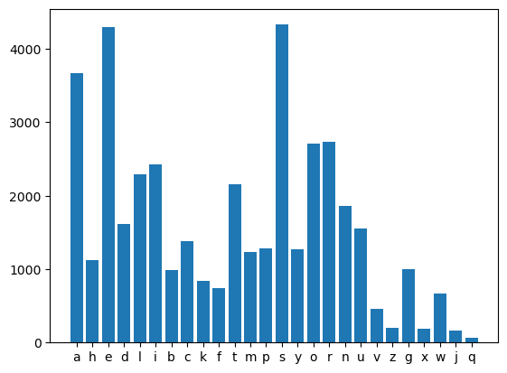

```python
letters_histogram = histogram(one_big_string)
plot_histogram(letters_histogram)
```

```python
print(letters_histogram)
```

```
{'a': 3665, 'h': 1122, 'e': 4303, 'd': 1611, 'l': 2293, 'i': 2428, 'b': 989, 'c': 1384, 'k': 838, 'f': 744, 't': 2154, 'm': 1239, 'p': 1285, 's': 4331, 'y': 1267, 'o': 2712, 'r': 2733, 'n': 1867, 'u': 1558, 'v': 453, 'z': 206, 'g': 1005, 'x': 188, 'w': 663, 'j': 162, 'q': 70}
```

To say for sure...

```python
#print( sorted(list(letters_histogram.values()), reverse=True)  )
```

```python
sorted_freqs = sorted(list(letters_histogram.values()), reverse=True)
sorted_freqs[:10]
```

```
[4331, 4303, 3665, 2733, 2712, 2428, 2293, 2154, 1867, 1611]
```

```python
for f in sorted_freqs[:7]:
    l = reverse_lookup(letters_histogram, f)
    print(f"{l} : {f : 4d}")
```

```
s :  4331
e :  4303
a :  3665
r :  2733
o :  2712
i :  2428
l :  2293
```

Now that we know the most common letters are, indeed, `searo`, we need to check if that is a word.

For that, we'll use another "old" function, this time from Week 8:

```python
def uses_all(word, must_have):
    for c in must_have:
        if (c not in word):
            return False
    return(True)
```

Then we can find a word the has the letters `searo`.

```python
for w in all_the_five_letter_words:
    if uses_all(w, "searo"):
        print(w)
```

```
arose
```

```python
len(all_the_five_letter_words)
```

```
8254
```

So, it would seem that `arose` is the best guess!

(Actually, this might not be true for several reasons, including that we should really use the actual dictionary of Wordle words).

# Word Frequency Analysis

This section is based on Chapter 13 of Think Python. Idea:

- Find the text of a classic book that is out of copyright.
- Read all the words from the file, stripping out white-space, etc.
- Report the 20 most common words
- Report the total number of different words used.

## Reading a file, and stripping white-space

> Exercise 1

Write a program that reads a file, breaks each line into words, strips whitespace and punctuation from the words, and converts them to lowercase. Hint: The `string` module provides a string named `whitespace`, which contains space, tab, newline, etc., and punctuation which contains the punctuation characters.

For a given book, we'll work as follows:

- `open` the book
- Make and empty `list()` that will store all the words.
- Use a `for` loop to read each line from the book
- "clean" the data with`strip` to remove the `\n` from the line,
- convert it to `lower()` case, and then `split()` it into a list.
- remove any punctuation from the end of words.
- add each word from that list to our main one.

We'll write this as a function.

There are several tasks to be done there. One of these is to strip whitespace and punctuation from a string. Python's `string` module can help: it defines strings `string.whitespace` and `string.punctuation`, which we can then strip. We do this because a word we read from a file could end with (say) `\n` or a full-stop or comma.

The string method `strip()` helps with this: if `s` is a string, then `s.strip(to_be_removed)` will return a string that is similar to `s` but any characters occurring in `to_be_removed` stripped from the start or end.

```python
import string
print(string.punctuation)
```

```
!"#$%&'()*+,-./:;<=>?@[\]^_`{|}~
```

```python
def clean_word(w):
    w = w.strip(string.whitespace)
    w = w.strip(string.punctuation)
    return w
```

Let's test this.

```python
my_word="\t...\npython;."
```

```python
print(my_word)
```

```
	...
python;.
```

```python
print(clean_word(my_word) )
```

```
python
```

Now we'll write a function to that reads all the lines from the file, splits them into words, "cleans" the words, and stores the result in a list.

```python
def get_all_words(file_name):
    try:
        fin = open(file_name)
    except:
        print(f"Can't open {file_name}.")
        return None
    all_words = []
    for line in fin:
        for word in line.split():
            word = clean_word(word).lower()
            all_words += [word]
    fin.close()
    return all_words
```

To test this, we'll make a small file of our own, called `TestFile.txt`. Its contents are

```
There are fifteen words in this file;
There are nine unique words in this file.
```

```python
test_words = get_all_words("TestFile.txt")
```

```python
print(f"There are {len(test_words)} words in the test file.")
print(word_list)
```

[output not shown]

## Unique words

Next we'll make a list of all the unique words in the list.

```python
def unique_words(big_list):
    unique_list = []
    for w in big_list:
        if w not in unique_list:
            unique_list += [w]
    return unique_list
```

Again, we'll test it with the contents of the data in `TestFile.txt`.

```python
test_words_unique = unique_words(test_words)
```

```python
print(f"There are {len(test_words_unique)} different words in the test file.")
```

```
There are 9 different words in the test file.
```

## The Novelty Score

Suppose we want to compare books to see which has the largest vocabulary. Since some books are much longer than others, we'll invent the "novelty score": $$ \frac{number-of-unique-words}{total-number-of-words}$$

We want to do this for several different books, to compare. The ones I've downloaded from Project Gutenberg: https://gutenberg.org/

- Alice's Adventures in Wonderlan (Lewis Carroll): `AliceInWonderLand.txt`
- Black Beauty (Anna Sewel): `BlackBeauty.txt`
- Dubliners (James Joyce): `Dubliners.txt`
- Frankenstein (Mary Shelly): `Frankenstein.txt`
- Pride and Prejudice (Jane Austen): `PrideAndPrejudice.txt`

```python
books = ["AliceInWonderLand.txt", "BlackBeauty.txt", "Dubliners.txt", "Frankenstein.txt",
         "PrideAndPrejudice.txt"]
```

```python
for b in books:
    full_list = get_all_words(b)
    unique_list = unique_words(full_list)
    novelty_score = len(unique_list)/len(full_list)
    print(f"{b:22s}: There are {len(unique_list):6d} different words. Novelty score: {novelty_score:.3f}")
```

```
AliceInWonderLand.txt : There are   4210 different words. Novelty score: 0.142
BlackBeauty.txt       : There are   5483 different words. Novelty score: 0.087
Dubliners.txt         : There are   9049 different words. Novelty score: 0.128
Frankenstein.txt      : There are   7977 different words. Novelty score: 0.102
PrideAndPrejudice.txt : There are   9023 different words. Novelty score: 0.069
```

The results here might be a little surprising. For example, as children's books, one might have expected smaller vocabularies for "Black Beauty" and "Alice" compared to, say, "Pride and Prejudice".

One explanation is that there are some "problems" with the data sets. For example, all of them start and end with lengthly preambles detailing licensing information. We'll return to this in our final lab...

Finished here Thursday